# **Tugas 3 Praktikum Metode Numerik**

Semester Genap Tahun Ajaran 2023/2024

Kembali ke Metode Numerik

## Petunjuk Umum:

1. Kerjakan secara individu.
2. Kerjakan tugas ini menggunakan bahasa pemrograman Python dengan file format berupa interactive Python notebook (yaitu file berbentuk **.ipynb** BUKAN .py), yang bisa dibuat misalnya menggunakan Jupyter Notebook atau Google Colaboratory.
3. **Harap sertakan penjelasan untuk setiap variabel yang digunakan dan setiap proses secara singkat** di samping potongan kode (dengan comment, ‘#’). Selain itu, **sertakan juga penjelasan program** (yang bisa mencakupi idenya apa, bagaimana cara eksekusi program, atau tentang algoritma program yang digunakan) **pada cell di sebelah (atas/bawah) program**.
4. Format nama file untuk Tugas 3 adalah:

   **Nama Lengkap_NPM_Kelas SIAK_Tugas3PrakMetnum.ipynb**

   Contoh penamaan yang benar:

   Luthfi Athallah Herdita Wiryaman_2206826980_Kelas G_Tugas3PrakMetnum.ipynb
5. Apabila ada yang ingin direvisi setelah pengumpulan, lakukan pengumpulan ulang di Google Forms yang sama, tambahkan keterangan bahwa ada revisi, dan tambahkan kata “revisi” pada bagian akhir nama file, contohnya menjadi

   Luthfi Athallah Herdita Wiryaman_2206826980_Kelas G_Tugas3PrakMetnum_revisi.ipynb

   Luthfi Athallah Herdita Wiryaman_2206826980_Kelas G_Tugas3PrakMetnum_revisi2.ipynb

   Luthfi Athallah Herdita Wiryaman_2206826980_Kelas G_Tugas3PrakMetnum_revisi3.ipynb

   **(Revisi boleh dilakukan berkali-kali.)**
6. Pengumpulan tugas dilakukan ke Google Forms berikut ini, sesuai dengan kelas Anda di SIAK NG (link akan selalu sama untuk semua tugas praktikum metode numerik):
   - Kelas A: https://forms.gle/AaWvGqEmY1nyx2d48
   - Kelas B: https://forms.gle/f433d9oJozgkdKZv5
   - Kelas C: https://forms.gle/iQbibikmgEacst8Z8
   - Kelas D: https://forms.gle/8F5D9hha2yEstd6z8
   - Kelas E: https://forms.gle/xz9fpedj9JLXHJH37
   - Kelas F: https://forms.gle/Ho7kbabuJUopkAP78
7. Durasi pengerjaan Tugas 3 ini adalah **2 (dua) minggu**, dan tenggat waktu (deadline) pengumpulan Tugas 3 ini adalah:

   **Minggu, 9 Juni 2024, pukul 23.59 WIB**.

   Mohon manfaatkan waktu Anda dengan baik (seperti mencicil pengerjaan, bahkan sudah selesai dari jauh-jauh hari) agar mengumpulkan tugas sebelum deadline. Keterlambatan pengumpulan bisa dikenakan pengurangan nilai atau bahkan dianggap tidak mengumpulkan, tergantung kesepakatan dari dosen. Meskipun demikian, lebih baik terlambat mengumpulkan daripada tidak mengumpulkan sama sekali.
8. Sesuai standar Universitas Indonesia, plagiarisme dilarang keras dan bisa menyebabkan nilai tugas praktikum menjadi nol untuk semua pihak yang terlibat, tanpa peringatan apapun.
9. *Module* atau *package* Python yang boleh digunakan (di-*import*) untuk Tugas 3 ini hanyalah NumPy, Tabulate, dan matplotlib. Apabila Anda berniat ingin menggunakan module lain, harap konfirmasikan ke narahubung terlebih dahulu (bisa saja diperbolehkan).
10. Narahubung untuk Tugas 3 Praktikum Metode Numerik adalah:
    - Zaki - LINE: linenyazaki
    - Pandu - LINE: pandyadaffa
    - Dahut - LINE: narendrahutapea
    - Dani - LINE: 123_dani

## **Soal Tugas 3 Praktikum Metode Numerik**

### **Ketentuan Soal**

Diberikan suatu fungsi $f:[1+k, 3+k]→\mathbb{R}$ dengan
$$\begin{equation}
f(x) = x\ln x
\end{equation}$$
dan $k = \text{(NPM)} \mod 5$. Kita bisa mengaproksimasi fungsi tersebut dalam bentuk polinomial berderajat $n=2$, misalkan $P_2(x)=a_2x^2+a_1x+a_0$, dengan menyelesaikan Sistem Persamaan Linier berikut
$$\begin{align}
a_0\int_a^bx^0dx+a_1\int_a^bx^1dx+a_2\int_a^bx^2dx&=\int_a^bx^0f(x)dx\\
a_0\int_a^bx^1dx+a_1\int_a^bx^2dx+a_2\int_a^bx^3dx&=\int_a^bx^1f(x)dx\\
a_0\int_a^bx^2dx+a_1\int_a^bx^3dx+a_2\int_a^bx^4dx&=\int_a^bx^2f(x)dx
\end{align}$$
Sistem persamaan tersebut disebut sebagai Persamaan Normal *(normal equations)* dengan $n=2$. Rumus umum dari Persamaan Normal (untuk sembarang $n$) adalah SPL berikut:
$$\begin{align}
\sum_{k=0}^na_k\int_a^bx^{j+k}dx=\int_a^bx^jf(x)dx, \text{ untuk setiap } j = 0,1,..., n
\end{align}$$
Solusi dari SPL tersebut merupakan koefisien-koefisien dari polinomial $P_n$. Dalam kasus polinomial berderajat dua di atas, solusi dari SPL tersebut secara berturut-turut menjadi nilai-nilai $a_0, a_1, a_2$.

(Kalau tertarik, kalian boleh saja baca lebih lanjut di subbab 8.2 buku Burden, atau bahkan mempelajari lebih lanjut di mata kuliah Matematika Numerik).

Buatlah program untuk menyelesaikan Persamaan Normal dari fungsi $f$ yang diberikan, dalam rangka menentukan aproksimasi polinomial berderajat dua $P_2$ dari $f$.

### **Tugas Integrasi Numerik**

**[40]** Gunakan salah satu dari metode berikut untuk mengaproksimasi hasil integral pada koefisien persamaan normal - Integrasi Numerik Komposit dengan banyaknya subinterval besar N = k + 10 (boleh menggunakan rumus khusus atau rumus umum dengan memilih salah satu metode Newton-Cotes) - Kuadratur Adaptif dengan metode Simpson (metode Simpson adaptif), dengan toleransi $10^{-5}$ dan faktor/pengkali toleransi = 10

### **Tugas SPL Iteratif**

- **[20]** Setelah didapatkan nilai koefisien dan konstanta dari persamaan normal tersebut pada langkah sebelumnya, selesaikan SPL tersebut secara iteratif menggunakan metode Gauss-Seidel dengan nilai awalnya adalah vektor nol $(0,0,...,0)$, toleransi = $10^{-5}$, dan maksimal banyaknya iterasi adalah $200$. Gunakan error absolut dan norm infinity untuk menghitung error pada tiap iterasi.
- **[20]** Tampilkan hasil $a_0, a_1, a_2$ pada tiap iterasi Gauss-Seidel dan nilai error pada iterasi tersebut dalam bentuk tabel.

### **Kerapian Program**

- **[10]** Keseluruhan program dikemas di dalam satu subprogram atau fungsi (*function*) yang bisa menerima sembarang fungsi $f$, interval $[a, b]$, NPM, toleransi dan faktor pengali (jika menggunakan metode kuadratur adaptif), serta toleransi dan maksimal banyaknya iterasi untuk metode Gauss-Seidel.
- **[10]** Program Anda bisa berjalan berulang kali (dengan beberapa kali *input* dan *output*) sesuai permintaan user, tanpa harus berhenti dan di-*run* ulang secara manual terlebih dahulu.

### **Bonus**

Ketentuan berikut tidak wajib kalian buat, namun apabila dikerjakan akan menjadi nilai tambah apabila terdapat kekurangan pada program yang telah kalian buat.

- Program dapat menampilkan hasil fungsi $P_2$ kemudian buat plot perbandingan fungsi $f$ dan $P_2$.
- Program dapat menerima sembarang nilai $n$ dan menghasilkan polinomial aproksimasi berderajat $n$.

## **Contoh Output Program** (disclaimer: contoh input kemungkinan berbeda dengan soal, dalam pengerjaan tetap pakai input soal)

```
Masukkan fungsi f yang ingin di aproksimasi: x*log(x)
Masukkan derajat polinomial aproksimasinya (bonus, boleh langsung dibuat n = 2): 2
Masukkan NPM anda: 2206026867
Nilai k yang digunakan adalah k = 2

Metode yang digunakan untuk integrasi numerik adalah metode komposit boole's rule dengan banyaknya subinterval besar adalah N = 12
Masukkan batas bawah interval: 1
Masukkan batas atas interval: 3

Interval yang digunakan adalah [3, 5]

Matriks diperbesar yang didapat menggunakan metode komposit boole's rule adalah:
[[  2.           8.          32.66666667  11.17421861]
 [  8.          32.66666667 136.          46.28351353]
 [ 32.66666667 136.         576.4        195.22777497]]

Akan digunakan metode Gauss-Seidel untuk menyelesaikan SPL
Masukkan besar toleransi error: 10**(-7)
Masukkan banyaknya iterasi maksimal: 100

Tabel hasil iterasi Gauss Seidel dari matriks diperbesar tersebut adalah
|   Iterasi |         x1 |        x2 |        x3 |        Error |
|-----------+------------+-----------+-----------+--------------|
|         0 |  0         | 0         | 0         | nan          |
|         1 |  5.58711   | 0.0485706 | 0.0106002 |   5.58711    |
|         2 |  5.21969   | 0.0944193 | 0.0206052 |   0.367418   |
|         3 |  4.87288   | 0.137699  | 0.0300485 |   0.346811   |
|         4 |  4.54552   | 0.178553  | 0.0389617 |   0.327359   |
|         5 |  4.23652   | 0.217119  | 0.0473743 |   0.308999   |
|         6 |  3.94485   | 0.253524  | 0.0553146 |   0.291669   |
|         7 |  3.66954   | 0.28789   | 0.0628089 |   0.275311   |
|         8 |  3.40967   | 0.32033   | 0.0698824 |   0.259871   |
|         9 |  3.16437   | 0.350954  | 0.0765587 |   0.245297   |
|        10 |  2.93283   | 0.379863  | 0.08286   |   0.231541   |
|        11 |  2.71428   | 0.407153  | 0.0888073 |   0.218556   |
|        12 |  2.50798   | 0.432915  | 0.0944206 |   0.206301   |
|        13 |  2.31324   | 0.457235  | 0.0997186 |   0.194732   |
|        14 |  2.12943   | 0.480194  | 0.104719  |   0.183813   |
|        15 |  1.95592   | 0.501868  | 0.109438  |   0.173507   |
|        16 |  1.79215   | 0.522329  | 0.113892  |   0.163778   |
```

[output cut: 70 more lines]

```
|        87 | -0.923575  | 0.863921  | 0.187205  |   0.00282434 |
|        88 | -0.926247  | 0.864296  | 0.187267  |   0.00267208 |
|        89 | -0.928775  | 0.864654  | 0.187326  |   0.00252837 |
|        90 | -0.931168  | 0.864994  | 0.187381  |   0.00239271 |
|        91 | -0.933432  | 0.865319  | 0.187433  |   0.00226467 |
|        92 | -0.935576  | 0.865629  | 0.187482  |   0.00214381 |
|        93 | -0.937606  | 0.865924  | 0.187527  |   0.00202973 |
|        94 | -0.939528  | 0.866206  | 0.187569  |   0.00192205 |
|        95 | -0.941348  | 0.866476  | 0.187609  |   0.00182041 |
|        96 | -0.943073  | 0.866733  | 0.187646  |   0.00172448 |
|        97 | -0.944707  | 0.866979  | 0.18768   |   0.00163392 |
|        98 | -0.946255  | 0.867215  | 0.187713  |   0.00154845 |
|        99 | -0.947723  | 0.86744   | 0.187743  |   0.00146776 |
Didapatkan nilai a_0 = -0.9477230349410641 a_1 = 0.8674398999199682 a_2 = 0.18774271522888558
Fungsi approksimasi berdasarkan data yang diberikan adalah (bonus): 0.18774271522888558 * x ** 2 + 0.8674398999199682 * x - 0.9477230349410641
```

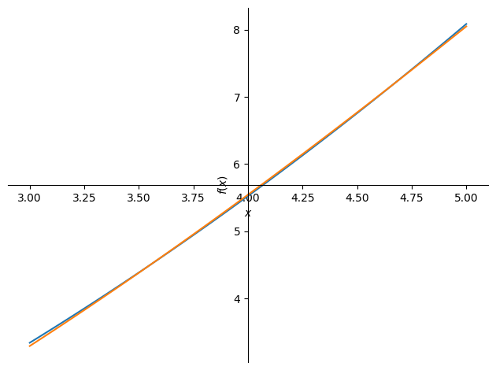

satu.png

```
Apakah Anda ingin menggunakan program ini lagi? (y/n): y

Masukkan fungsi f yang ingin di aproksimasi: x*log(x)
Masukkan derajat polinomial aproksimasinya (bonus, boleh langsung dibuat n = 2): 3
Masukkan NPM anda: 2206026867
Nilai k yang digunakan adalah k = 2

Metode yang digunakan untuk integrasi numerik adalah metode komposit boole's rule dengan banyaknya subinterval besar adalah N = 12
Masukkan batas bawah interval: 3
Masukkan batas atas interval: 5

Interval yang digunakan adalah [5, 7]

Matriks diperbesar yang didapat menggunakan metode komposit boole's rule adalah:
[[2.00000000e+00 1.20000000e+01 7.26666667e+01 4.44000000e+02 1.31200258e+02]
 [1.20000000e+01 7.26666667e+01 4.44000000e+02 2.73640000e+03 8.05557893e+02]
 [7.26666667e+01 4.44000000e+02 2.73640000e+03 1.70040000e+04 4.98780368e+03]
 [4.44000000e+02 2.73640000e+03 1.70040000e+04 1.06488286e+05 3.11304860e+04]]

Akan digunakan metode Gauss-Seidel untuk menyelesaikan SPL
Masukkan besar toleransi error: 10**(-7)
Masukkan banyaknya iterasi maksimal: 100

Tabel hasil iterasi Gauss Seidel dari matriks diperbesar tersebut adalah
|   Iterasi |         x1 |       x2 |        x3 |        x4 |       Error |
|-----------+------------+----------+-----------+-----------+-------------|
|         0 |   0        | 0        | 0         | 0         | nan         |
|         1 |  65.6001   | 0.25261  | 0.0397245 | 0.0059848 |  65.6001    |
|         2 |  61.3125   | 0.492567 | 0.0774602 | 0.0116702 |   4.28761   |
|         3 |  57.2396   | 0.720503 | 0.113307  | 0.017071  |   4.07295   |
|         4 |  53.3705   | 0.937021 | 0.147359  | 0.0222017 |   3.86904   |
|         5 |  49.6952   | 1.14269  | 0.179706  | 0.0270757 |   3.67533   |
|         6 |  46.2039   | 1.33806  | 0.210433  | 0.0317058 |   3.49132   |
|         7 |  42.8874   | 1.52364  | 0.239623  | 0.0361043 |   3.31652   |
|         8 |  39.7369   | 1.69992  | 0.26735   | 0.0402827 |   3.15047   |
|         9 |  36.7441   | 1.86736  | 0.29369   | 0.0442521 |   2.99274   |
|        10 |  33.9012   | 2.02642  | 0.318711  | 0.048023  |   2.84289   |
|        11 |  31.2007   | 2.1775   | 0.342479  | 0.0516052 |   2.70055   |
|        12 |  28.6354   | 2.32102  | 0.365057  | 0.0550082 |   2.56533   |
|        13 |  26.1985   | 2.45734  | 0.386504  | 0.058241  |   2.43688   |
```

[output cut: 73 more lines]

```
|        87 | -18.9691   | 4.97634  | 0.784067  | 0.118353  |   0.0537255 |
|        88 | -19.0201   | 4.97906  | 0.784516  | 0.118424  |   0.0509959 |
|        89 | -19.0685   | 4.98163  | 0.784943  | 0.118492  |   0.048403  |
|        90 | -19.1145   | 4.98406  | 0.785348  | 0.118556  |   0.0459398 |
|        91 | -19.1581   | 4.98637  | 0.785732  | 0.118618  |   0.0436    |
|        92 | -19.1995   | 4.98855  | 0.786097  | 0.118676  |   0.0413773 |
|        93 | -19.2387   | 4.99061  | 0.786443  | 0.118731  |   0.0392658 |
|        94 | -19.276    | 4.99255  | 0.786771  | 0.118784  |   0.03726   |
|        95 | -19.3113   | 4.9944   | 0.787083  | 0.118835  |   0.0353547 |
|        96 | -19.3449   | 4.99614  | 0.787379  | 0.118883  |   0.0335447 |
|        97 | -19.3767   | 4.99778  | 0.78766   | 0.118928  |   0.0318253 |
|        98 | -19.4069   | 4.99933  | 0.787926  | 0.118972  |   0.030192  |
|        99 | -19.4355   | 5.0008   | 0.788179  | 0.119013  |   0.0286404 |
Didapatkan nilai a_0 = -19.435538369145267 a_1 = 5.000797855866304 a_2 = 0.788178630037227 a_3 = 0.11901301847757702
Fungsi approksimasi berdasarkan data yang diberikan adalah (bonus): 0.11901301847757702 * x ** 3 + 0.788178630037227 * x ** 2 + 5.000797855866304 * x - 19.435538369145267
```

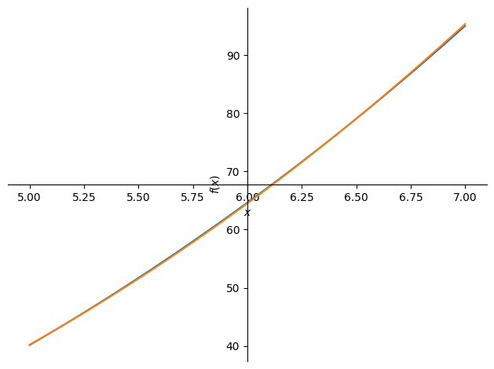

dua.png

```
Apakah Anda ingin menggunakan program ini lagi? (y/n) n
Terima kasih telah menggunakan program ini.
```